How to Data

# How to add details to a plot

## Description

After making a plot, we might want to add axis labels, a title, gridlines, or text. Plotting packages provide tons of tools for this sort of thing. What are some of the essentials?

Related tasks:

- How to create basic plots
- How to create a histogram
- How to create a box (and whisker) plot
- How to change axes, ticks, and scale in a plot
- How to create bivariate plots to compare groups
- How to plot interaction effects of treatments

## Using Matplotlib, in Python

View this solution alone.

We will create some fake data using Python lists, for simplicity. But everything we show below works also if your data is in columns of a DataFrame, such as `df['age']`.

```python
patient_height = [  60,  64,  64,  65,  66,  66,  70,  72,  72,  76 ]
patient_weight = [ 141, 182, 169, 204, 138, 198, 180, 175, 244, 196 ]
```

The conventional way to import matplotlib in Python is as follows.

```python
import matplotlib.pyplot as plt
```

The following code creates a plot with many details added, but each is independent of the others, so you can take just the bit of code that you need.

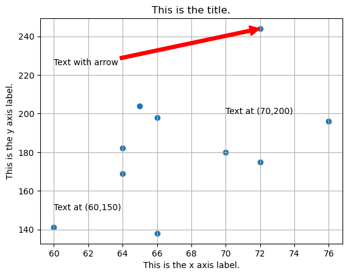

```python
plt.scatter( patient_height, patient_weight )
plt.xlabel( 'This is the x axis label.' )
plt.ylabel( 'This is the y axis label.' )
plt.title( 'This is the title.' )
plt.grid()                                     # Turns on gridlines
plt.text( 70, 200, 'Text at (70,200)' )        # Text method 1
plt.annotate( 'Text at (60,150)', (60,150) )   # Text method 2
plt.annotate( 'Text with arrow', xytext=(60,225), xy=(72,244),
              arrowprops={'color':'red'} )     # Text with arrow
plt.show()
```

Content last modified on 24 July 2023.

See a problem? [Tell us](https://github.com/nathancarter/how2data/issues/new/choose) or edit the source.

## Solution, in R

View this solution alone.

We will create some fake data using R vectors, for simplicity. But everything we show below works also if your data is in columns of a data frame, such as `df$age`.

```r
patient_height <- c(  60,  64,  64,  65,  66,  66,  70,  72,  72,  76 )
patient_weight <- c( 141, 182, 169, 204, 138, 198, 180, 175, 244, 196 )
```

The following code creates a plot with many details added, but each is independent of the others, so you can take just the bit of code that you need.

```r
plot( patient_height, patient_weight,
      main="This is the title.",
      xlab="This is the x axis label.",
      ylab="This is the y axis label." )   # Scatter plot with labels
grid()                                     # Turns on gridlines
text( 70, 200, "Text at (70,200)" )        # Add text
text( 65, 225, "Point 1", pos=2 )          # Text to the left of a point
text( 72, 244, "Point 2", pos=4 )          # Text to the right of a point
arrows( 65, 225, 72, 244, col='red' )      # Arrow from (65,225) to (72,244)
```

[figure not shown]

Content last modified on 24 July 2023.

See a problem? [Tell us](https://github.com/nathancarter/how2data/issues/new/choose) or edit the source.

## Topics that include this task

- Bentley University MA346

## Opportunities

This website does not yet contain a solution for this task in any of the following software packages.

- Excel
- Julia

If you can contribute a solution using any of these pieces of software, see our Contributing page for how to help extend this website.